# Medindo a concordância entre o *ranking* e a *expert list*

Autor

Fernando Náufel

Data de Publicação

07/02/2024 12:05

# Setup

```r
source('_setup.R')
```

```
[conflicted] Will prefer tibble::view over any other package.
[conflicted] Will prefer dplyr::filter over any other package.
```

# O problema

# Temporada 2022

## Leitura e limpeza

```r
df <- readxl::read_xlsx('planilhas/2022 BB DWARFF.xlsx') %>%
  clean_names() %>%
  select(player:dwarff_bb, -x0_0) %>%
  mutate(
    across(
      vorp_g:dwarff_bb,
      ~ as.numeric(str_replace(.x, ',', '.'))
    )
  ) %>%
  rename(
    time = tm,
    jogos = g,
    minutos_jogados = mp,
    vorp_j = vorp_g,
    cestas_j = fg_g,
    bpm_j = bpm_g,
    assist_pct_j = ast_percent_g,
    rebote_def_j = drb_g,
    lances_livres_j = ft_g,
    bloqueios_j = blk_g
  )
```

```r
glimpse(df)
```

```
Rows: 812
Columns: 15
$ player          <chr> "Nikola Jokić", "Giannis Antetokounmpo", "Joel…
$ pos             <chr> "C", "PF", "C", "PG", "PG", "SF", "PG", "PG", …
$ time            <chr> "DEN", "MIL", "PHI", "DAL", "ATL", "BOS", "MEM…
$ jogos           <dbl> 74, 67, 68, 65, 76, 76, 57, 65, 55, 68, 65, 64…
$ minutos_jogados <dbl> 2476, 2204, 2297, 2301, 2652, 2731, 1889, 2139…
$ vorp_j          <dbl> 10,0, 7,8, 7,0, 6,5, 5,5, 5,5, 4,6, 4,7, 5,5, …
$ cestas_j        <dbl> 9,9, 8,9, 8,6, 8,3, 9,2, 9,1, 7,5, 4,7, 7,5, 8…
$ bpm_j           <dbl> 10,0, 8,7, 7,7, 7,2, 5,6, 5,5, 6,1, 5,7, 6,6, …
$ tw_g            <dbl> 7,5, 8,0, 8,0, 8,1, 6,7, 8,0, 8,8, 10,0, 6,9, …
$ assist_pct_j    <dbl> 9,2, 6,7, 4,9, 10,0, 10,2, 4,3, 7,3, 9,7, 6,1,…
$ drtg_g          <dbl> 8,4, 7,9, 8,4, 7,4, 1,6, 7,9, 5,3, 7,4, 4,7, 6…
$ rebote_def_j    <dbl> 10,0, 7,9, 8,0, 6,6, 2,9, 6,4, 3,1, 3,2, 4,6, …
$ lances_livres_j <dbl> 5,8, 8,5, 10,0, 5,6, 7,6, 6,1, 4,8, 2,6, 5,7, …
$ bloqueios_j     <dbl> 3,6, 5,1, 5,6, 2,0, 0,4, 2,8, 1,2, 1,1, 2,9, 1…
$ dwarff_bb       <dbl> 30,2, 28,4, 27,1, 26,5, 23,2, 22,7, 22,6, 22,6…
```

## Resumo

```r
df %>% dfSummary() %>% print(method = 'render')
```

```
temporary images written to '/home/fnaufel/Documents/DataAnalysis/NBA-Orlando/2024-DWARFF-Romulo/dfimg'
```

| **Variável** | **Estatísticas / Valores** | **Freqs (% de Válidos)** | **Grafo** | **Faltante** |
| --- | --- | --- | --- | --- |
| player [character] | 1. Greg Monroe 2. Alize Johnson 3. Danuel House Jr. 4. Isaiah Thomas 5. James Ennis III 6. Jeff Dowtin 7. Juancho Hernangómez 8. Justin Robinson 9. Luke Kornet 10. Tomáš Satoranský [ 595 outros ] | 5 ( 0,6% ) 4 ( 0,5% ) 4 ( 0,5% ) 4 ( 0,5% ) 4 ( 0,5% ) 4 ( 0,5% ) 4 ( 0,5% ) 4 ( 0,5% ) 4 ( 0,5% ) 4 ( 0,5% ) 771 ( 95,0% ) |  | 0 (0,0%) |
| pos [character] | 1. SG 2. PG 3. SF 4. PF 5. C 6. SF-SG 7. SG-PG 8. SG-SF 9. C-PF 10. PF-SF [ 2 outros ] | 198 ( 24,4% ) 156 ( 19,2% ) 153 ( 18,8% ) 150 ( 18,5% ) 140 ( 17,2% ) 4 ( 0,5% ) 4 ( 0,5% ) 3 ( 0,4% ) 1 ( 0,1% ) 1 ( 0,1% ) 2 ( 0,2% ) |  | 0 (0,0%) |
| time [character] | 1. TOT 2. MIL 3. WAS 4. BOS 5. IND 6. DAL 7. DET 8. POR 9. CLE 10. OKC [ 21 outros ] | 97 ( 11,9% ) 29 ( 3,6% ) 29 ( 3,6% ) 28 ( 3,4% ) 28 ( 3,4% ) 27 ( 3,3% ) 27 ( 3,3% ) 27 ( 3,3% ) 26 ( 3,2% ) 26 ( 3,2% ) 468 ( 57,6% ) |  | 0 (0,0%) |
| jogos [numeric] | Média (dp) : 36,7 (25,9) mín < mediana < máx: 1 < 36,5 < 82 IQE (CV) : 49 (0,7) | 82 valores distintos |  | 0 (0,0%) |
| minutos_jogados [numeric] | Média (dp) : 825,2 (775,8) mín < mediana < máx: 1 < 577,5 < 2854 IQE (CV) : 1293,5 (0,9) | 625 valores distintos |  | 0 (0,0%) |
| vorp_j [numeric] | Média (dp) : 1,5 (0,9) mín < mediana < máx: 0 < 1,1 < 10 IQE (CV) : 0,5 (0,6) | 53 valores distintos |  | 0 (0,0%) |
| cestas_j [numeric] | Média (dp) : 1,8 (2) mín < mediana < máx: 0 < 1 < 10 IQE (CV) : 2,6 (1,1) | 82 valores distintos |  | 0 (0,0%) |
| bpm_j [numeric] | Média (dp) : 1,1 (1,7) mín < mediana < máx: 0 < 0 < 10 IQE (CV) : 2,4 (1,5) | 65 valores distintos |  | 0 (0,0%) |
| tw_g [numeric] | Média (dp) : 2,6 (3,4) mín < mediana < máx: 0 < 0 < 10 IQE (CV) : 5,8 (1,3) | 24 valores distintos |  | 0 (0,0%) |
| assist_pct_j [numeric] | Média (dp) : 1,2 (1,9) mín < mediana < máx: 0 < 0 < 10,2 IQE (CV) : 1,8 (1,6) | 76 valores distintos |  | 0 (0,0%) |
| drtg_g [numeric] | Média (dp) : 1,8 (2,6) mín < mediana < máx: 0 < 0 < 10 IQE (CV) : 3,7 (1,4) | 20 valores distintos |  | 0 (0,0%) |
| rebote_def_j [numeric] | Média (dp) : 1,4 (1,6) mín < mediana < máx: 0 < 0,9 < 10 IQE (CV) : 2 (1,1) | 70 valores distintos |  | 0 (0,0%) |
| lances_livres_j [numeric] | Média (dp) : 0,9 (1,2) mín < mediana < máx: 0 < 0,4 < 10 IQE (CV) : 1,1 (1,4) | 59 valores distintos |  | 0 (0,0%) |
| bloqueios_j [numeric] | Média (dp) : 0,9 (1,2) mín < mediana < máx: 0 < 0,5 < 10 IQE (CV) : 1,1 (1,3) | 53 valores distintos |  | 0 (0,0%) |
| dwarff_bb [numeric] | Média (dp) : 5,3 (6,5) mín < mediana < máx: 0 < 0,9 < 30,2 IQE (CV) : 10,8 (1,2) | 156 valores distintos |  | 0 (0,0%) |

Gerado por summarytools 1.0.1 ([R](https://www.r-project.org/) versão 4.3.1)  
2024-02-07

## Jogadores repetidos

Alguns jogadores aparecem mais de uma vez, porque jogaram em mais de um time na temporada.

```r
df %>%
  add_count(player) %>%
  filter(n > 1) %>%
  select(player, time) %>%
  group_by(player) %>%
  summarize(
    times = paste0(time, collapse = ' ')
  )
```

| player | times |
| --- | --- |
| Aaron Holiday | TOT WAS PHO |
| Alize Johnson | TOT CHI NOP WAS |
| Andre Drummond | TOT PHI BRK |
| Armoni Brooks | TOT HOU TOR |
| Brad Wanamaker | TOT IND WAS |
| Braxton Key | TOT DET PHI |
| Bruno Fernando | TOT HOU BOS |
| Bryn Forbes | TOT SAS DEN |
| Buddy Hield | TOT SAC IND |
| CJ McCollum | TOT POR NOP |

[output cut: 87 more lines]

**O que fazer com as estatísticas?**

O que fazer com as estatísticas destes jogadores?

Agregar? Como?

## Posições

- PG = point guard, armador
- SG = shooting guard, ala-armador
- SF = small forward, ala
- PF = power forward, ala de força
- C = center, pivô

(de https://pt.wikipedia.org/wiki/Posi%C3%A7%C3%B5es_no_basquetebol)

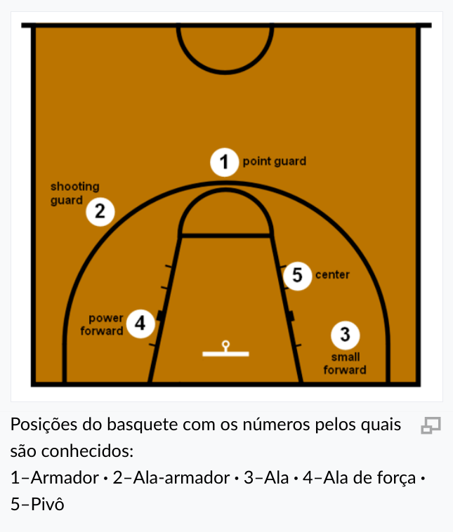

**Jogadores multiposição**

Alguns pouquíssimos jogadores jogam em mais de uma posição:

```r
df %>%
  filter(str_detect(pos, '-')) %>%
  select(player, pos) %>%
  arrange(pos)
```

| player | pos |
| --- | --- |
| Larry Nance Jr. | C-PF |
| Rodney Hood | PF-SF |
| Lance Stephenson | PG-SG |
| Norman Powell | SF-SG |
| Jeremy Lamb | SF-SG |
| Justin Holiday | SF-SG |
| Malcolm Hill | SF-SG |
| Tyrese Haliburton | SG-PG |
| CJ McCollum | SG-PG |
| Armoni Brooks | SG-PG |

[output cut: 5 more lines]

O ideal seria criar um registro para cada posição, todos os registros com o mesmo *score*.

O único risco disto seria um jogador ser previsto para aparecer duas vezes na *expert list* (uma vez para cada posição).

Vou considerar este risco desprezível.

## *Expert list*

```r
lista <- c(
  'Nikola Jokić',
  'Giannis Antetokounmpo',
  'Jayson Tatum',
  'Luka Dončić',
  'Devin Booker',
  'Joel Embiid',
  'Kevin Durant',
  'DeMar DeRozan',
  'Ja Morant',
  'Stephen Curry',
  'Karl-Anthony Towns',
  'LeBron James',
  'Pascal Siakam',
  'Chris Paul',
  'Trae Young'
)
```

São 15 jogadores no total.

```r
df %>%
  filter(player %in% lista) %>%
  arrange(player) %>%
  select(player)
```

| player |
| --- |
| Chris Paul |
| DeMar DeRozan |
| Devin Booker |
| Giannis Antetokounmpo |
| Ja Morant |
| Jayson Tatum |
| Joel Embiid |
| Karl-Anthony Towns |
| Kevin Durant |
| LeBron James |

[output cut: 5 more lines]

## Posições novamente

Vamos adicionar as posições à lista e eliminar as repetições (se houver):

```r
lista_com_pos <- tibble(player = lista) %>%
  left_join(df, by = 'player') %>%
  select(player, pos) %>%
  distinct()

lista_com_pos
```

| player | pos |
| --- | --- |
| Nikola Jokić | C |
| Giannis Antetokounmpo | PF |
| Jayson Tatum | SF |
| Luka Dončić | PG |
| Devin Booker | SG |
| Joel Embiid | C |
| Kevin Durant | PF |
| DeMar DeRozan | PF |
| Ja Morant | PG |
| Stephen Curry | PG |

[output cut: 5 more lines]

```r
time1 <- lista_com_pos %>% slice(1:5)
time1
```

| player | pos |
| --- | --- |
| Nikola Jokić | C |
| Giannis Antetokounmpo | PF |
| Jayson Tatum | SF |
| Luka Dončić | PG |
| Devin Booker | SG |

```r
time2 <- lista_com_pos %>% slice(6:10)
time2
```

| player | pos |
| --- | --- |
| Joel Embiid | C |
| Kevin Durant | PF |
| DeMar DeRozan | PF |
| Ja Morant | PG |
| Stephen Curry | PG |

```r
time3 <- lista_com_pos %>% slice(11:15)
time3
```

| player | pos |
| --- | --- |
| Karl-Anthony Towns | C |
| LeBron James | C |
| Pascal Siakam | PF |
| Chris Paul | PG |
| Trae Young | PG |

**Posições desconsideradas**

Realmente, não dá para considerar as posições. Aqui, só o primeiro time foi “padrão”.

## Topo do *ranking*

O *ranking* com todos:

```r
df_ranking <- df %>%
  group_by(player) %>%
  slice_max(dwarff_bb, n = 1) %>%
  ungroup() %>%
  arrange(desc(dwarff_bb)) %>%
  select(player, time, dwarff_bb) %>%
  mutate(expert_list = player %in% lista)

df_ranking
```

| player | time | dwarff_bb | expert_list |
| --- | --- | --- | --- |
| Nikola Jokić | DEN | 30,2 | TRUE |
| Giannis Antetokounmpo | MIL | 28,4 | TRUE |
| Joel Embiid | PHI | 27,1 | TRUE |
| Luka Dončić | DAL | 26,5 | TRUE |
| Trae Young | ATL | 23,2 | TRUE |
| Jayson Tatum | BOS | 22,7 | TRUE |
| Chris Paul | PHO | 22,6 | TRUE |
| Ja Morant | MEM | 22,6 | TRUE |
| Kevin Durant | BRK | 22,0 | TRUE |
| Devin Booker | PHO | 21,9 | TRUE |

[output cut: 624 more lines]

**Desempate**

Quando um jogador aparecia mais de uma vez, considerei o registro de maior DWARFF.

Qual a pior posição no *ranking* de um jogador da lista?

```r
contando_do_fim <- which.max(rev(df_ranking$expert_list))
contando_do_inicio <- nrow(df_ranking) - contando_do_fim + 1
contando_do_inicio
```

```
[1] 19
```

```r
df_ranking %>% slice(contando_do_inicio)
```

| player | time | dwarff_bb | expert_list |
| --- | --- | --- | --- |
| Pascal Siakam | TOR | 19,7 | TRUE |

# Decisões

## Jogadores repetidos

- Romulo disse que usou o *team wins* do time onde o jogador jogou por último.
- O mesmo vale para as outras estatísticas?

## Posições

- Ignorar as posições totalmente, já que os próprios *experts* não respeitam as posições na hora de definir a lista.